# Analyse données exuvies état-zéro 2022-2023

Thibaut Couturier

Analyse en date du 2024-11-19

# Exploration des données

| date | site | passage1 | passage2 | passage3 |
| --- | --- | --- | --- | --- |
| 2022-06-16 | TGF | 49 | 0 | 0 |
| 2022-06-17 | RNM | 82 | 0 | 0 |
| 2022-06-17 | TGF | 20 | 0 | 0 |
| 2022-06-18 | RNM | 21 | 0 | 0 |
| 2022-07-18 | TGF | 0 | 43 | 0 |
| 2022-07-19 | RNM | 0 | 66 | 0 |
| 2022-07-19 | TGF | 0 | 15 | 0 |
| 2022-07-20 | RNM | 0 | 30 | 0 |
| 2022-08-08 | RNM | 0 | 0 | 73 |
| 2022-08-09 | RNM | 0 | 0 | 17 |
| 2022-08-16 | TGF | 0 | 0 | 58 |
| 2023-05-31 | TDC | 57 | 0 | 0 |
| 2023-06-01 | TDC | 84 | 0 | 0 |
| 2023-06-28 | TDC | 0 | 105 | 0 |
| 2023-06-29 | TDC | 0 | 16 | 0 |
| 2023-08-10 | TDC | 0 | 0 | 96 |
| 2023-08-11 | TDC | 0 | 0 | 16 |

116 placettes étaient positives, c’est-à-dire avec au moins une exuvie collectée au cours des différents passages.

## Abondances exuvies (placettes positives uniquement)

Au total, 2632 exuvies d’anisoptères ont été collectées.

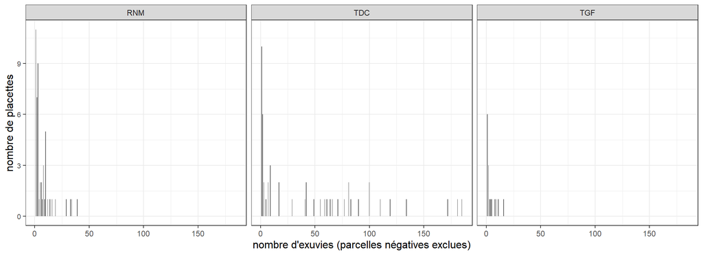

## Richesses placettes (placettes positives uniquement)

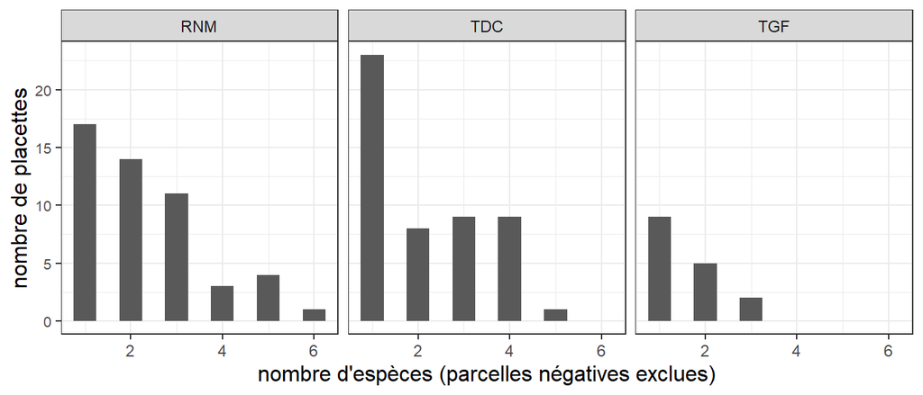

## Bilan par espèce et par site

| espece | tot_exuvies_RNM | tot_exuvies_TDC | tot_exuvies_TGF | tot_placettes_RNM | tot_placettes_TDC | tot_placettes_TGF |
| --- | --- | --- | --- | --- | --- | --- |
| aeshna grandis | 1 | 0 | 0 | 1 | 0 | 0 |
| aeshna_cyanea | 45 | 6 | 4 | 7 | 4 | 2 |
| aeshna_grandis | 0 | 1 | 0 | 0 | 1 | 0 |
| aeshna_juncea | 5 | 1 | 4 | 5 | 1 | 4 |
| aeshna_subarctica_elisabethae | 78 | 7 | 1 | 19 | 2 | 1 |
| anax_imperator | 0 | 60 | 0 | 0 | 9 | 0 |
| cordulia_aenae | 0 | 64 | 0 | 0 | 21 | 0 |
| cordulia_aenea | 17 | 0 | 0 | 12 | 0 | 0 |
| indetermine | 8 | 0 | 0 | 8 | 0 | 0 |
| leucorrhinia_dubia | 37 | 1989 | 47 | 16 | 32 | 8 |
| libellula_quadrimaculata | 13 | 0 | 0 | 8 | 0 | 0 |
| libellula_quatrimaculata | 0 | 27 | 0 | 0 | 11 | 0 |
| somatochlora_alpestris | 0 | 0 | 4 | 0 | 0 | 4 |
| somatochlora_arctica | 30 | 30 | 8 | 18 | 18 | 6 |
| sympetrum_danae | 130 | 15 | 0 | 22 | 8 | 0 |

## Durées de prospection

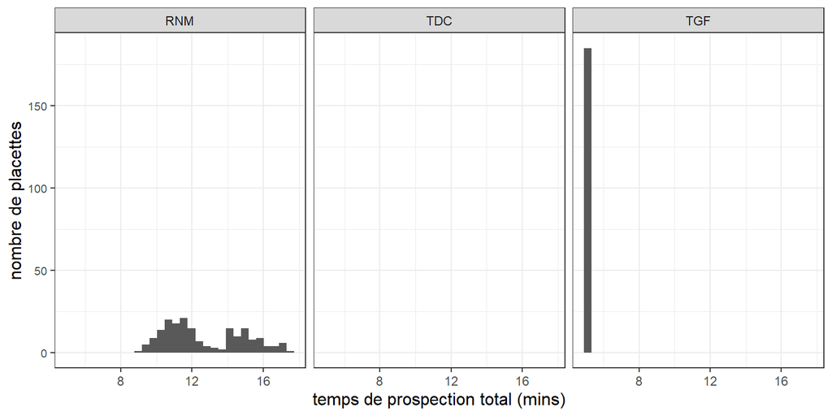

Sur RNM, on n’observe pas de différence de durée de prospection selon la typologie d’habitat.

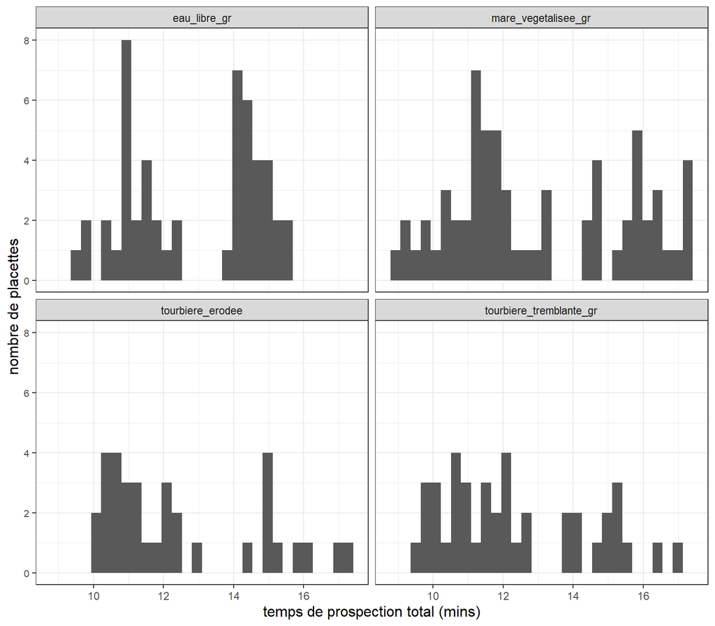

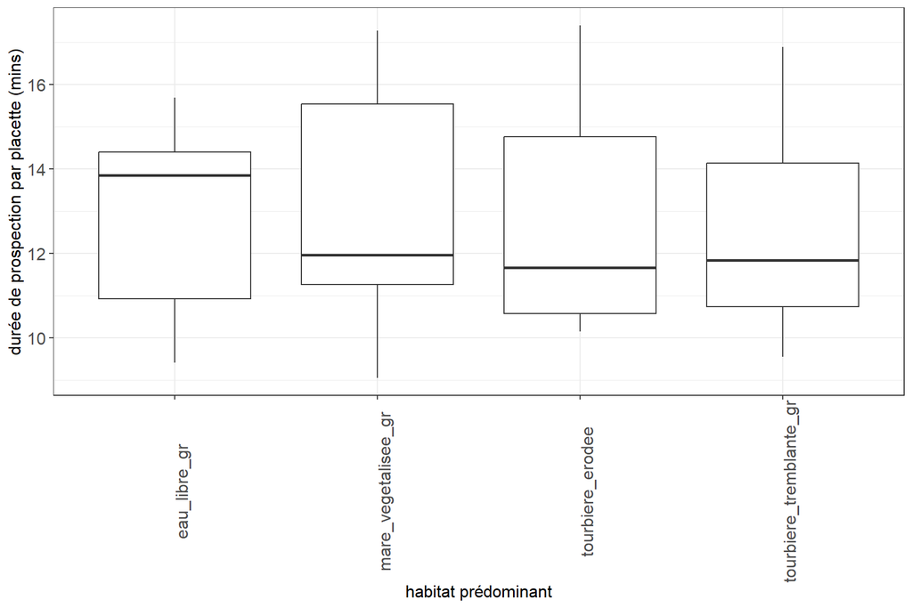

## Cartos placettes

TGF

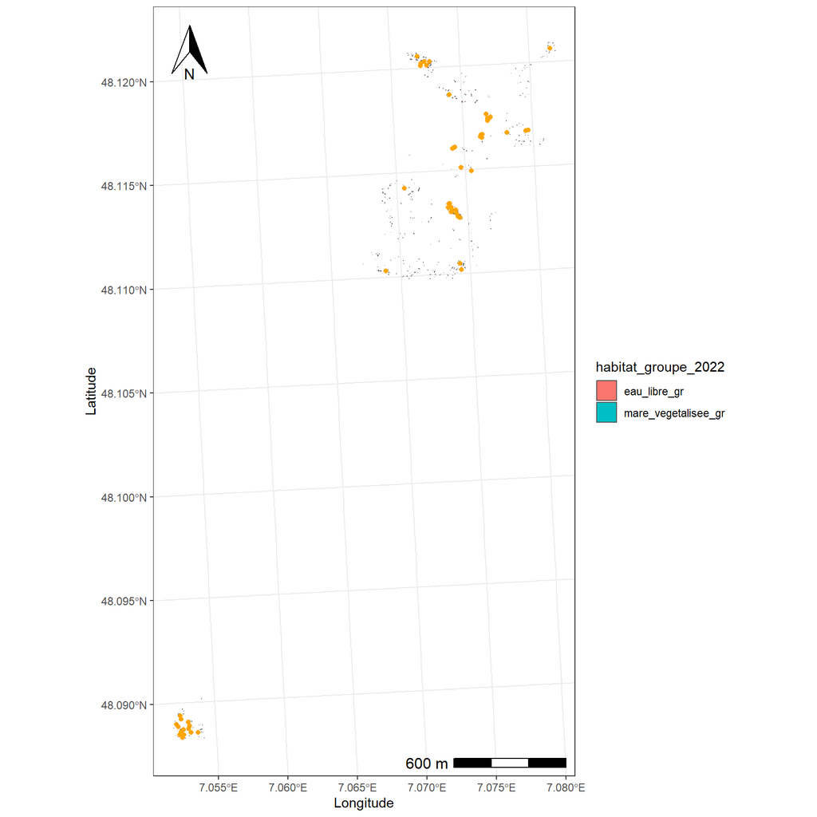

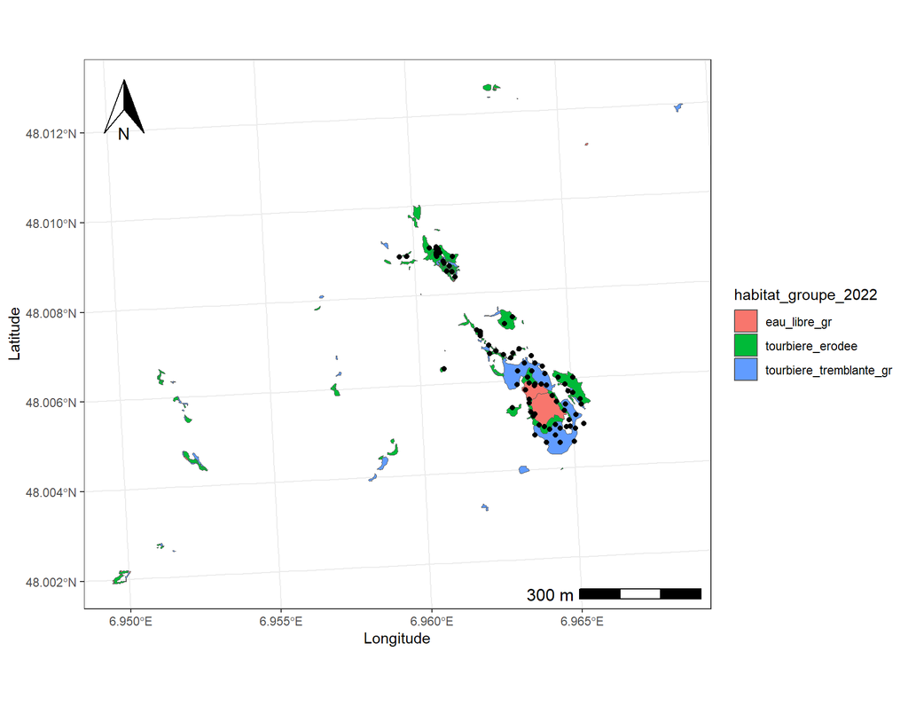

## Bilans selon variables terrain

### Typologies habitats

| habitat_predominant | tot_exuvies_RNM | tot_exuvies_TDC | tot_exuvies_TGF | tot_placettes_RNM | tot_placettes_TDC | tot_placettes_TGF |
| --- | --- | --- | --- | --- | --- | --- |
| eau_libre_gr | 64 | 2059 | 66 | 20 | 25 | 29 |
| mare_vegetalisee_gr | 247 | 16 | 2 | 20 | 25 | 29 |
| tourbiere_erodee | 16 | 0 | 0 | 20 | 0 | 0 |
| tourbiere_tremblante_gr | 37 | 4 | 0 | 20 | 25 | 0 |
| carex_rostrata | 0 | 121 | 0 | 0 | 25 | 0 |

## Phénologie

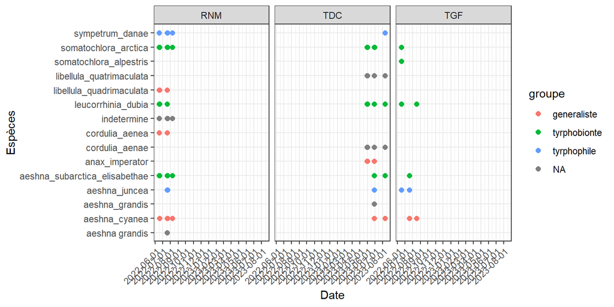

# Modélisation

## Vérification des corrélations entre covariables

La profondeur (linéaire) et la présence d’eau sont fortement corrélées ; ces deux variables ne seront pas ajustées sur le même paramètre d’un même modèle.

|  | Eau_libre | Helophytes | profondeur_lin |
| --- | --- | --- | --- |
| Eau_libre | 1.00 | 0.30 | 0.74 |
| Helophytes | 0.30 | 1.00 | 0.26 |
| profondeur_lin | 0.74 | 0.26 | 1.00 |

## Préparation des données pour unmarked

Trois jeux de données sont préparés, avec regroupement d’espèces : libellules tyrphobiontes, tyrpohophiles, et généralistes/tolérantes.

## Tyrphobiontes

### Sélection de modèles

```
##                                               model   n nPars AIC delta   AICwt
## 20 p(periode_cat+eau+site) psi(profondeur_max+site) 238    10 503     0 1.0e+00
## 17                p(periode_cat+eau+site) psi(site) 238     9 528    25 4.2e-06
## 18      p(periode_cat+eau+site) psi(profondeur_max) 238     8 529    26 2.1e-06
## 14                   p(periode_cat+eau+site) psi(.) 238     7 531    27 1.1e-06
## 16             p(periode_cat+eau+site) psi(habitat) 238    11 532    29 5.1e-07
## 19                 p(periode_cat+eau+site) psi(eau) 238     8 533    29 4.4e-07
## 9                         p(periode_cat+eau) psi(.) 238     5 544    40 1.9e-09
## 15            p(periode_cat+site+profondeur) psi(.) 238     7 563    60 1.1e-13
## 11                 p(periode_cat+profondeur) psi(.) 238     5 572    68 1.4e-15
## 10                       p(periode_cat+site) psi(.) 238     6 606   103 5.4e-23
## 12                               p(eau+site) psi(.) 238     5 626   123 2.4e-27
## 4                                     p(eau) psi(.) 238     3 632   129 1.1e-28
## 3                             p(periode_cat) psi(.) 238     4 633   129 8.0e-29
## 2                                 p(periode) psi(.) 238     3 635   131 2.9e-29
## 13                        p(site+profondeur) psi(.) 238     5 644   140 3.5e-31
## 8                              p(profondeur) psi(.) 238     3 648   145 3.2e-32
## 6                                 p(habitat) psi(.) 238     6 671   168 4.1e-37
## 5                                    p(site) psi(.) 238     4 688   184 9.6e-41
## 7                              p(helophytes) psi(.) 238     3 702   198 8.2e-44
## 1                                       p(.) psi(.) 238     2 711   208 7.0e-46
```

Le modèle retenu est celui prenant en compte l’effet de la période, de la présence d’eau et du site sur la probabilité de détection, et de la profondeur et du site sur la probabilité d’occupation des tyrphobiontes.

### Prédictions

La probabilité d’occupation moyenne des tyrphobiontes estimée par le modèle constant est psi = 0.49 [IC95% 0.41-0.57]. La probabilité de détection des tyrphobiontes estimée par le modèle constant est p = 0.46 [IC95% 0.39-0.54].

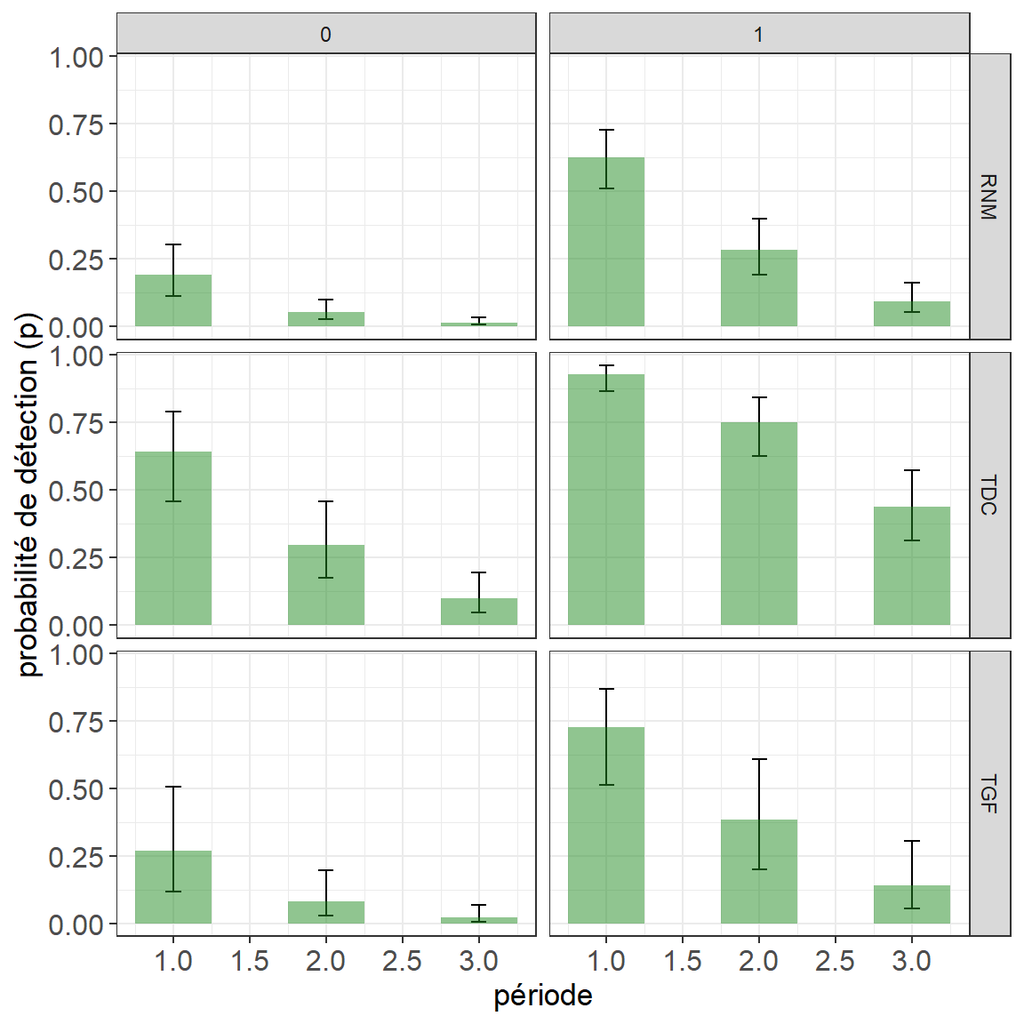

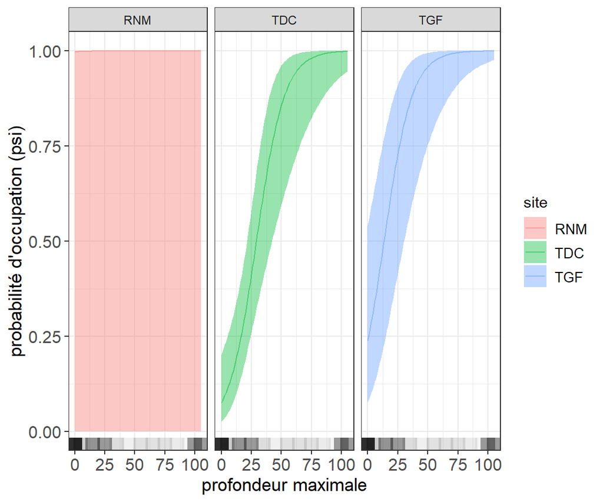

## Tyrphophiles

### Sélection de modèles

```
##                                          model   n nPars AIC delta   AICwt
## 21 p(periode_cat+eau+site) psi(profondeur_max) 238     8 245   0.0 9.3e-01
## 22            p(periode_cat+eau+site) psi(eau) 238     8 251   5.9 4.9e-02
## 17              p(periode_cat+eau+site) psi(.) 238     7 255   9.2 9.2e-03
## 19        p(periode_cat+eau+site) psi(habitat) 238    11 255   9.4 8.3e-03
## 20           p(periode_cat+eau+site) psi(site) 238     9 258  12.7 1.7e-03
## 18           p(periode_cat+eau+habitat) psi(.) 238     9 264  18.6 8.6e-05
## 9                    p(periode_cat+eau) psi(.) 238     5 270  24.9 3.6e-06
## 13                          p(eau+site) psi(.) 238     5 273  27.2 1.2e-06
## 14                       p(eau+habitat) psi(.) 238     7 280  34.8 2.5e-08
## 4                                p(eau) psi(.) 238     3 286  40.1 1.8e-09
## 16                      p(site+habitat) psi(.) 238     8 288  42.2 6.3e-10
## 10                  p(periode_cat+site) psi(.) 238     6 290  44.6 2.0e-10
## 11            p(periode_cat+profondeur) psi(.) 238     5 291  45.2 1.5e-10
## 15                   p(site+profondeur) psi(.) 238     5 298  52.2 4.3e-12
## 12               p(periode_cat+habitat) psi(.) 238     8 302  56.6 4.8e-13
## 5                               p(site) psi(.) 238     4 306  60.5 6.9e-14
## 3                        p(periode_cat) psi(.) 238     4 309  63.2 1.8e-14
## 8                         p(profondeur) psi(.) 238     3 309  63.6 1.4e-14
## 2                            p(periode) psi(.) 238     3 314  68.6 1.2e-15
## 6                            p(habitat) psi(.) 238     6 318  72.4 1.8e-16
## 7                         p(helophytes) psi(.) 238     3 322  76.0 2.9e-17
## 1                                  p(.) psi(.) 238     2 324  78.9 7.0e-18
```

Le meilleur modèle intègre des effets additifs de la période, de la présence d’eau et du site sur la probabilité de détection et un effet de la profondeur maximale d’eau (parmi les trois visites) sur la probabilité d’occupation des tyrphophiles.

### Prédictions

La probabilité d’occupation moyenne des tyrphophiles estimée par le modèle constant est psi = 0.41 [IC95% 0.18-0.68]. La probabilité de détection des tyrphophiles estimée par le modèle constant est p = 0.15 [IC95% 0.07-0.28].

**Meilleur modèle** La probabilité de détection des tyrphopiles est plus élevée sur Machais, puis TGF, elle augmente lorsqu’il y a présence d’eau sur les placettes, elles est faible lors de la période 1.

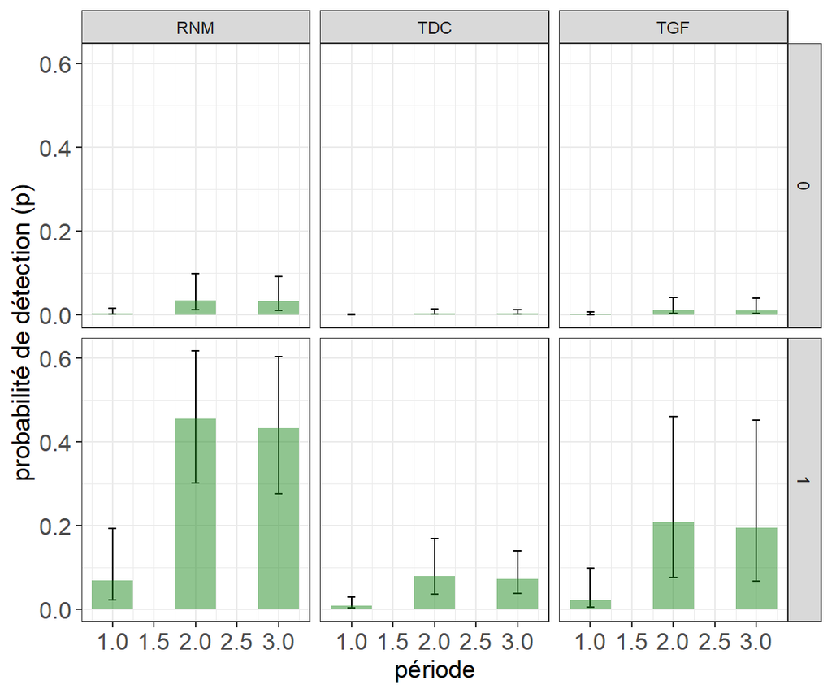

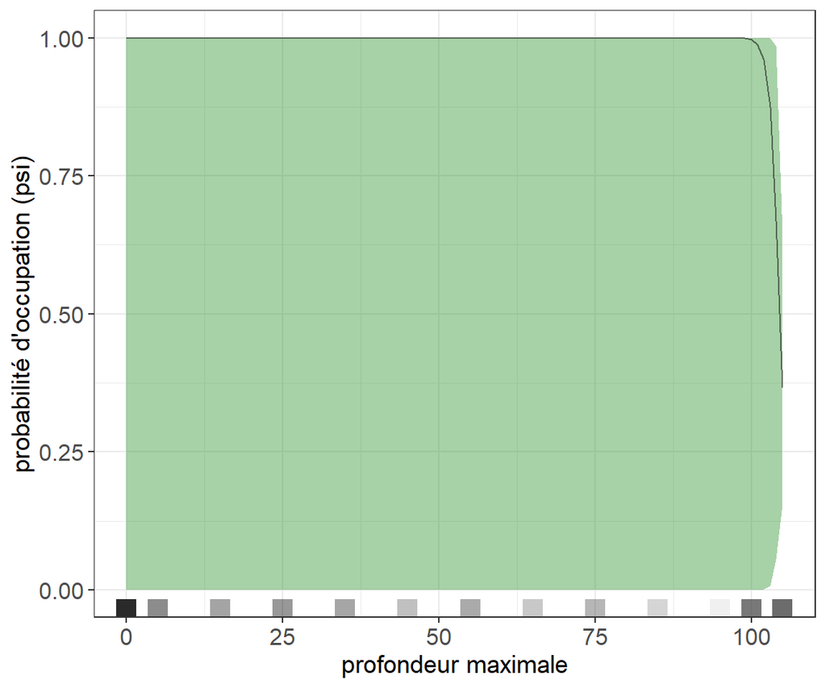

## Généralistes

### Sélection de modèles

```
##                                              model   n nPars AIC   delta
## 21 p(periode+eau) psi(habitat+profondeur_max+site) 238    11 245  0.0000
## 20      p(periode+eau) psi(habitat+profondeur_max) 238     9 245  0.0086
## 19 p(periode+eau+site) psi(profondeur_max+habitat) 238    11 248  2.9296
## 24          p(periode) psi(habitat+profondeur_max) 238     8 250  5.2856
## 17         p(periode+eau+site) psi(profondeur_max) 238     7 253  8.5146
## 15                p(periode+eau+site) psi(habitat) 238    10 253  8.5723
## 22              p(periode+eau) psi(profondeur_max) 238     5 254  9.4664
## 23                     p(periode+eau) psi(habitat) 238     8 259 13.7968
## 14                      p(periode+eau+site) psi(.) 238     6 260 14.9914
## 16                   p(periode+eau+site) psi(site) 238     8 261 16.5979
## 18                    p(periode+eau+site) psi(eau) 238     7 262 16.9909
## 9                            p(periode+eau) psi(.) 238     4 265 20.1414
## 25              p(eau) psi(habitat+profondeur_max) 238     8 266 21.3889
## 11                    p(periode+profondeur) psi(.) 238     4 281 36.4400
```

[output cut: 37 more lines]

Le modèle retenu intègre les effets additifs de la présence d’eau et de la période sur la probabilité de détection, ainsi que des effets de l’habitat et de la profondeur maximale en eau sur l’occupation des libellules généralistes.

### Prédictions

La probabilité d’occupation moyenne des généralistes estimée par le modèle constant est psi = 0.24 [IC95% 0.15-0.36]. La probabilité de détection des généralistes estimée par le modèle constant est p = 0.28 [IC95% 0.17-0.41].

**Meilleur modèle**  
Les prédictions du meilleur modèle mettent en évidence une augmentation de la probabilité de détection des libellules généralistes avec la présence d’eau, et une diminution linéaire de leur probabilité de détection avec l’avancée de la saison. Ce modèle met également en évidence une augmentation de la probabilité d’occupation avec la profondeur maximale d’eau (lors de la session avec le niveau d’eau maximal parmi les trois sessions). On n’observe pas de différence entre les habitats d’eau libre et mares végétalisées. La probabilité d’occupation est nulle sur les habitats de tourbières trembantes (aucune exuvie détectée). Elle est mal estimée pour les tourbières errodées (trop peu de détections ?).

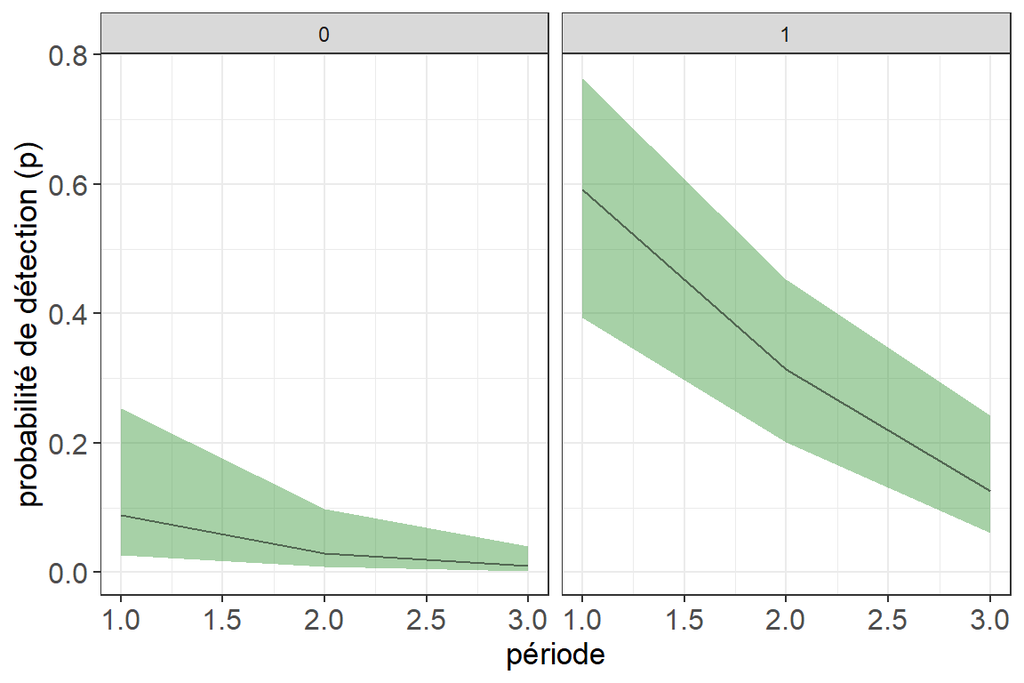

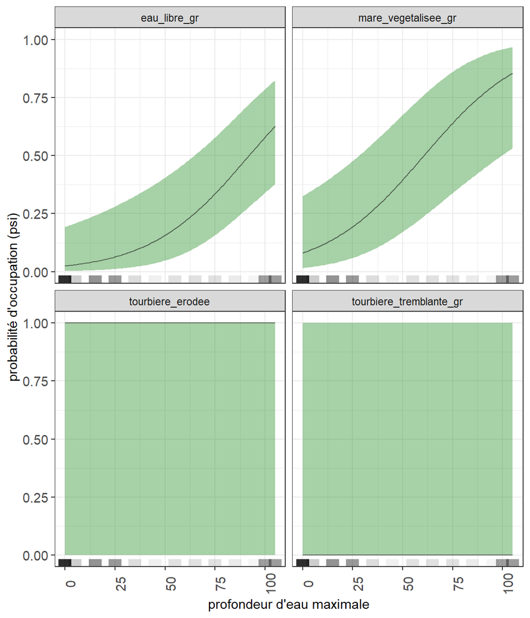